# Gestão de Carteiras de Investimento

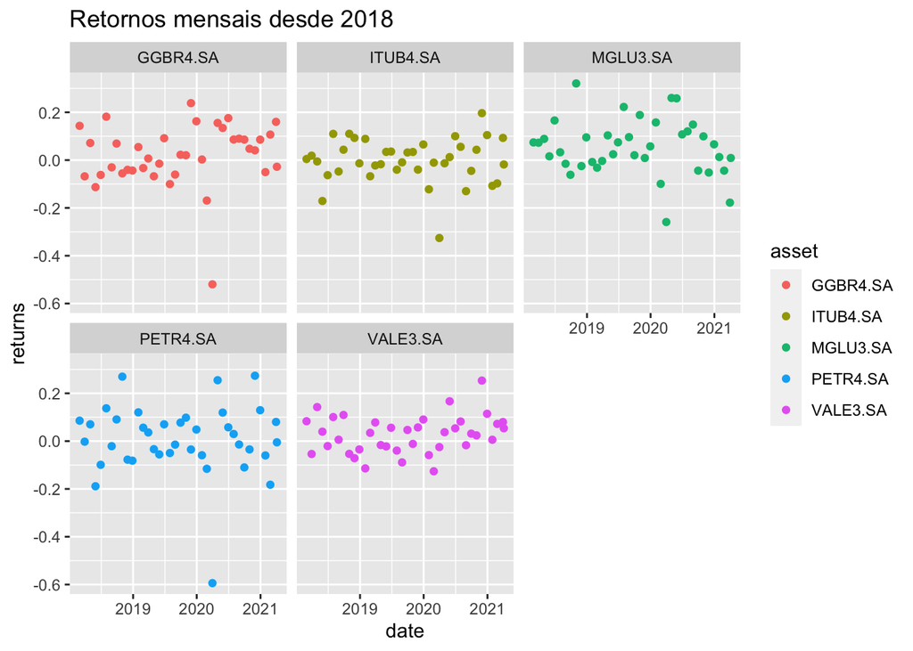

```r
asset_returns_long %>% ggplot(aes(y = returns, x=date, color = asset)) +
                       geom_point() +
                       ggtitle("Retornos mensais desde 2018") + facet_wrap(~asset)
```

Risco dos ativos

Desvio padrão dos ativos individuais no período:

```r
sdevAtivos <- asset_returns_long %>%
  group_by(asset) %>%
  summarise( sd = sd(returns), retorno_medio_mensal = mean(returns))

sdevAtivos
```

```
## # A tibble: 5 x 3
##   asset        sd retorno_medio_mensal
## * <chr>     <dbl>                <dbl>
## 1 GGBR4.SA 0.130               0.0199
## 2 ITUB4.SA 0.0933             -0.00235
## 3 MGLU3.SA 0.115               0.0533
## 4 PETR4.SA 0.147               0.00697
## 5 VALE3.SA 0.0785              0.0273
```

Começamos com uma carteira composta pelos dois ativos com menos desvio padrão no período. Esses são os ativos cujas ações representaram a menor variação média de preços no período analisado.

```r
w <- c(0, 0, 0.5, 0, 0.5)
```

Checamos que os pesos estão corretamente alinhados

```r
tibble(w, symbols)
```

```
## # A tibble: 5 x 2
##       w symbols
##   <dbl> <chr>
## 1   0   PETR4.SA
## 2   0   MGLU3.SA
## 3   0.5 VALE3.SA
## 4   0   GGBR4.SA
## 5   0.5 ITUB4.SA
```

```r
tibble(w, symbols) %>% summarise(total_weight = sum(w))
```

```
## # A tibble: 1 x 1
##   total_weight
##          <dbl>
## 1            1
```

Usando o pacote tidyquant, começamos com o objeto formatado asset_returns_long, e podemos calcular os retornos de portfolios formados a partir desses ativos utilizando a função tq_portfolio(). Essa função parte de um objeto com retornos, e tem como input uma coluna que determina os ativos para o portfólio, uma coluna para encontrar os retornos e uma coluna para os pesos. A função também aceita o argumento rebalance_on = “months”, que calcula automaticamente o rebalanceamento do portfolio para garantir que os pesos definidos se mantenham.

```r
portfolio_returns_tq_rebalanced_monthly <- asset_returns_long %>%
  tq_portfolio(assets_col = asset,
               returns_col = returns,
               weights = w,
               col_rename = "returns",
               rebalance_on = "months")
```

Visualizando os retornos do portfolio:

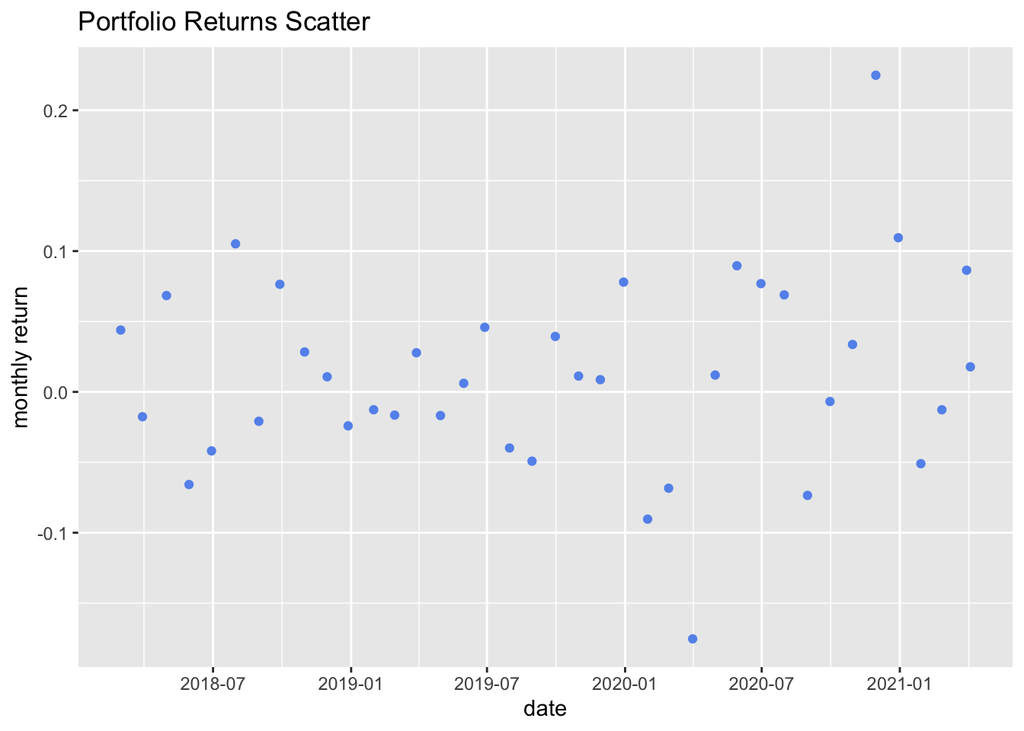

```r
portfolio_returns_tq_rebalanced_monthly %>%
  ggplot(aes(x = date, y = returns)) +
  geom_point(colour = "cornflowerblue")+
  xlab("date") +
  ylab("monthly return") +
  theme_update(plot.title = element_text(hjust = 0.5)) +
  ggtitle("Portfolio Returns Scatter") +
  scale_x_date(breaks = pretty_breaks(n=6))
```

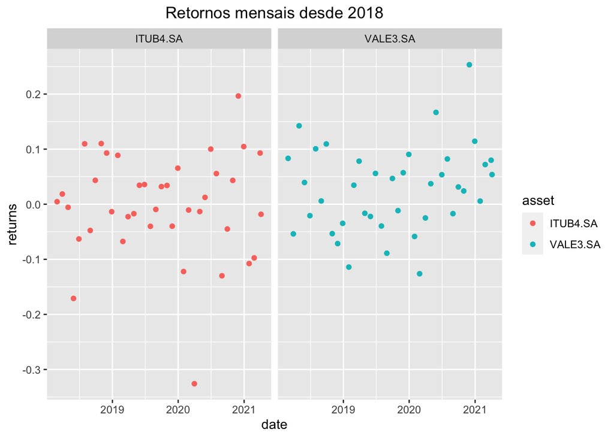

```r
asset_returns_long %>% filter(asset%in%c("VALE3.SA","ITUB4.SA")) %>%  ggplot(aes(y = returns, x=date, color = asset)) +
                       geom_point() +
                       ggtitle("Retornos mensais desde 2018") + facet_wrap(~asset)
```

Os retornos do portfolio são menos voláteis que os retornos dos ativos individuais.

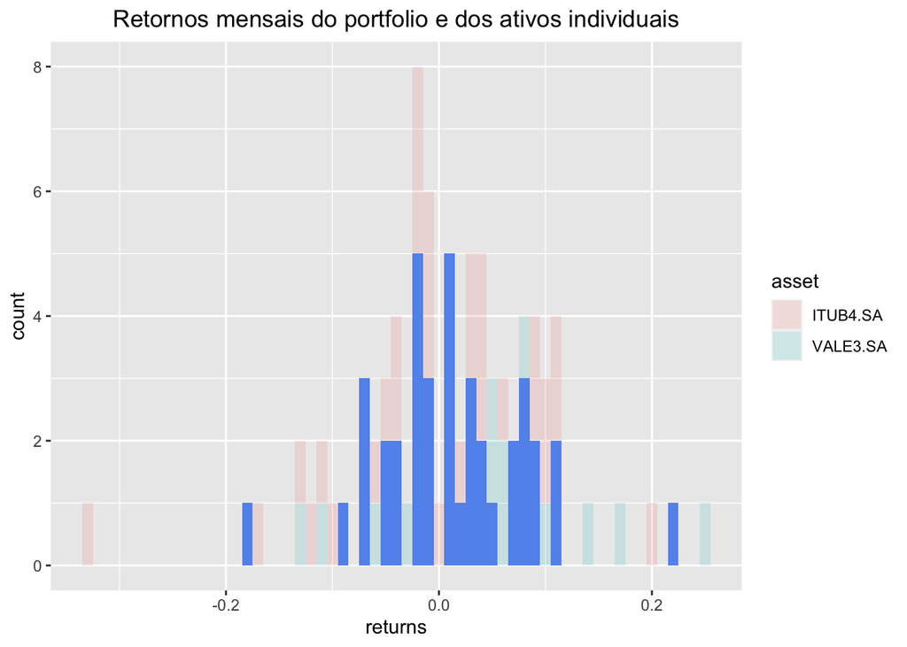

```r
asset_returns_long %>% filter(asset%in%c("VALE3.SA","ITUB4.SA")) %>%
            ggplot(aes(x = returns, fill = asset)) +
            geom_histogram(alpha = 0.15, binwidth = .01) +
            geom_histogram(data = portfolio_returns_tq_rebalanced_monthly,
                           fill = "cornflowerblue",
                           binwidth = .01) +
            ggtitle("Retornos mensais do portfolio e dos ativos individuais") +
            theme_update(plot.title = element_text(hjust = 0.5))
```

```r
sd(portfolio_returns_tq_rebalanced_monthly$returns)
```

```
## [1] 0.06946139
```

Comparando o desvio padrão do portfolio com o desvio padrão individual de ITUB4.SA (0.09333882) e VALE3.SA (0.07849913), notamos que o portfolio tem risco menor do que os riscos individuais dos ativos que o compõem.

Isso ocorre por conta da estrutura de correlação entre esses ativos. Coeficientes de correlação imperfeitos, que não dejam iguais a 1 ou -1, fazem com que seja possível diminuir o risco de uma carteira por conta de combinações entre ativos correlacionados.

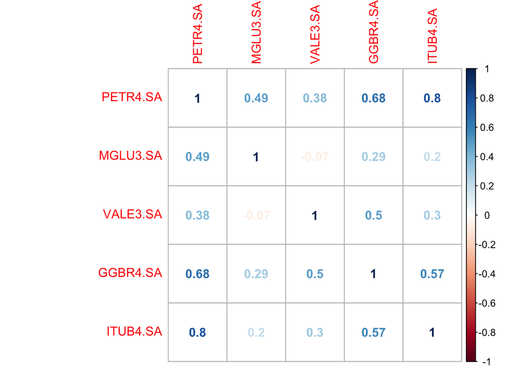

```r
corrplot(cor(returns[,2:6]), method="number")
```

Uma questão que pode ocorrer é, se reduzimos o risco com uma combinação com peso igual para dois ativos, será que não poderíamos atingir uma redução ainda maior com outra proporção? E será que não poderíamos conseguir mais reduções de risco se adicionássemos mais ativos à carteira?